# CFPB Consumer Complaint Database Exploratory Data Analysis

05/07/15

## Introduction

- [Consumer Financial Protection Bureau (CFPB)](http://www.consumerfinance.gov/) [Consumer Complaint Database](https://catalog.data.gov/dataset/consumer-complaint-database)
  - Number of complaints: 377850
  - Number of variables: 14
  - Number of companies: 2850
  - Number of unique complaint issues: 96
  - Date range: 2011-12-01 to 2015-04-28
  - Data retrieved from [Data.gov](https://www.data.gov/)
- Topics covered in this presentation
  - [Data cleaning](https://github.com/mspcvsp/ConsumerComplaintDatabase/blob/gh-pages/dataCleaning.R)
  - Visualization of state-level statistics via [chroopleths](https://github.com/trulia/choroplethr)
  - Plotting zipcode-level statistics using the [ggmap package](http://journal.r-project.org/archive/2013-1/kahle-wickham.pdf)

## Data Cleaning

- Transform the variable names to lower case
- Remove periods from variable names
- Exclude data from U.S. territories
- Apply a maximum percent missing threshold to remove partial observations
- Remove whitespace from the company type
- For each database character variable value:
  - Transform to lower case
  - Remove punctuation
  - Replace multiple spaces with a single space

## Data Cleaning (cont.)

- Remove white space from the company type
- Aggregate the 96 complaint issues into 12 categories
- Append city, state, latitude, & longitude from the [zipcode R package](https://jeffreybreen.wordpress.com/2011/01/05/cran-zipcode/)
- Add a companyid variable
- Convert date variables
- Convert categorical (i.e. [factor](http://statistics.ats.ucla.edu/stat/r/modules/factor_variables.htm)) variables
- Percentage of data removed during data cleaning: 11.4%

## Percentage of Missing Data

- Results suggest 2 variables exceed the maximum percentage of missing data threshold of 10 %.

| Variable | % Missing |
| --- | --- |
| subissue | 69.50 |
| subproduct | 31.00 |
| consumerdisputed | 8.40 |
| zipcode | 0.50 |
| complaintid | 0.00 |
| product | 0.00 |
| issue | 0.00 |
| state | 0.00 |
| submittedvia | 0.00 |
| datereceived | 0.00 |
| datesenttocompany | 0.00 |
| company | 0.00 |
| companyresponse | 0.00 |
| timelyresponse | 0.00 |

## Frequency of Complaints

- Estimated temporal occurrence of consumer complaints

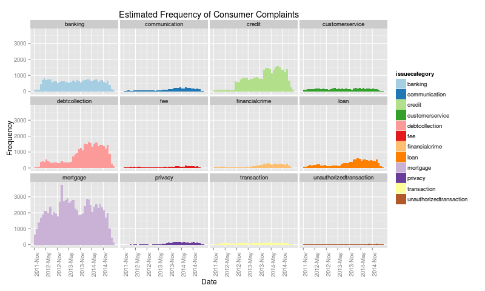

## Issue Category Percentage

- Results suggest that mortgage, debtcollection, credit, banking, & loan are the top five consumer complaint issue categories

| issuecategory | percentoccurence |
| --- | --- |
| mortgage | 41.20 |
| debtcollection | 15.30 |
| credit | 14.60 |
| banking | 11.20 |
| loan | 5.70 |
| customerservice | 2.80 |
| financialcrime | 2.60 |
| communication | 2.00 |
| transaction | 1.60 |
| fee | 1.30 |
| privacy | 1.30 |
| unauthorizedtransaction | 0.30 |

## Percentage of Mortgage Category Complaints

- Estimated percentage of mortgage category consumer complaints for each U.S. state [choropleth](http://blog.crisis.net/choropleth-maps-with-d3/)

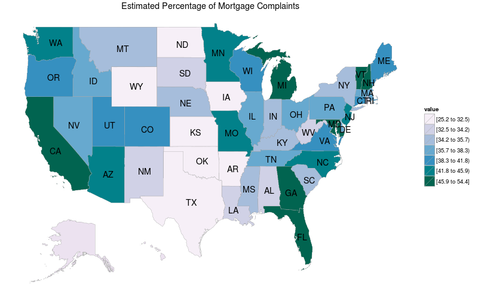

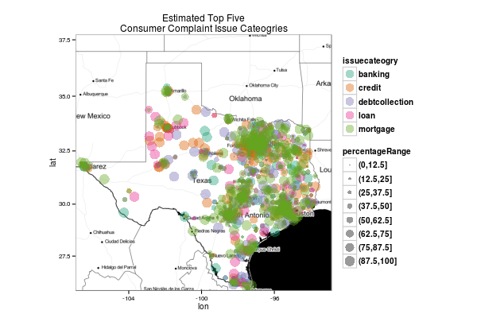

- [D. Kahle and H. Wickham. ggmap: Spatial Visualization with ggplot2. The R Journal, 5(1), 144-161.](http://journal.r-project.org/archive/2013-1/kahle-wickham.pdf)
- Map tiles by [Stamen Design](http://stamen.com/), under [CC BY 3.0.](http://creativecommons.org/licenses/by/3.0/) Data by [OpenStreetMap](http://www.openstreetmap.org/), under [ODbL](http://www.openstreetmap.org/copyright).

## Debt Collection Category Percentage

- Estimated percentage of debt collection category consumer complaints for each U.S. state

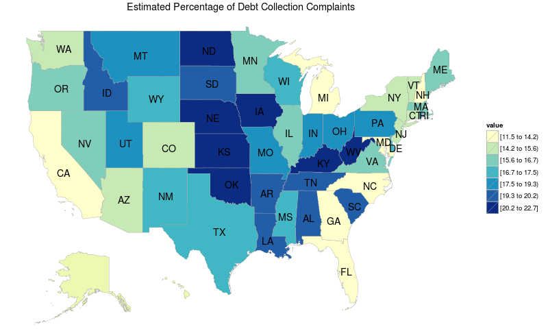

## Credit Category Percentage

- Estimated percentage of credit category consumer complaints for each U.S. state

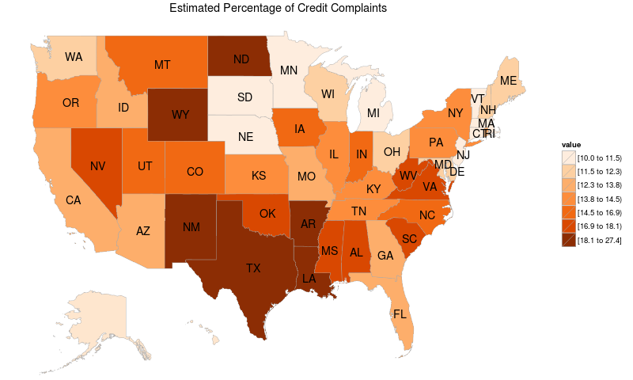

## Banking Category Percentage

- Estimated percentage of banking category consumer complaints for each U.S. state

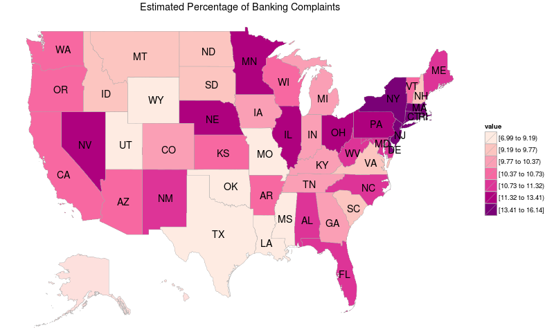

## Percentage Submitted Via

- Estimated percent submitted via

  | web | referral | phone | postal mail | fax | email |
  | --- | --- | --- | --- | --- | --- |
  | 61.40 | 23.00 | 7.50 | 6.50 | 1.50 | 0.10 |

- Estimated percentage submitted via the web

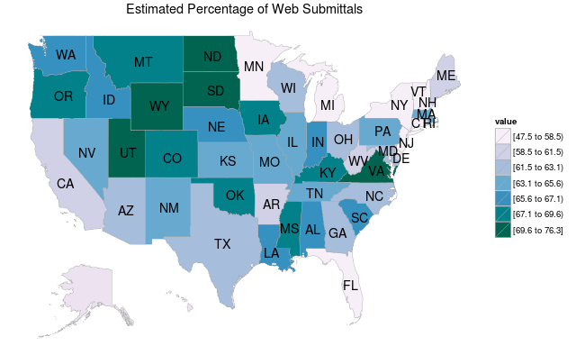

## Distribution of complaints / companyid

- Results suggest that number of complaints submitted for most companies in the CFPB Consumer Complaint Database is relatively low

| companyid | 279 | 2302 | 1178 | 466 | 785 | 767 | 1570 | 2166 |
| --- | --- | --- | --- | --- | --- | --- | --- | --- |
| percentage | 12.47 | 8.94 | 6.83 | 4.97 | 4.78 | 4.70 | 4.37 | 3.52 |
| cumulativepercentage | 12.47 | 21.40 | 28.23 | 33.20 | 37.99 | 42.69 | 47.06 | 50.58 |

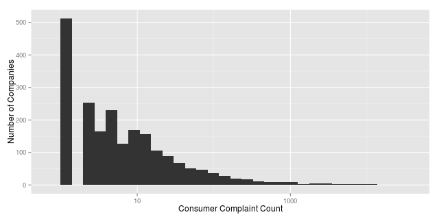

## Conclusion

- Introduced a procedure for preparing the [Consumer Financial Protection Bureau (CFPB)](http://www.consumerfinance.gov/) [Consumer Complaint Database](https://catalog.data.gov/dataset/consumer-complaint-database) for analysis
- Illustrated the following types of exploratory data analysis plots
  - [Choropleth](http://blog.crisis.net/choropleth-maps-with-d3/)
  - [Geospatial data visualization](http://journal.r-project.org/archive/2013-1/kahle-wickham.pdf)
- Exploratory data analysis results suggest
  - Significant consumer complaint issue category geospatial and temporal variation
  - The number of complaints for most companies is relatively low
- Potential directions for future analysis
  - Investigate the stability of zipcode level statistics for each U.S. state
  - Evaluate the dependency of the complaint issue category variable on the the timelyresponse, consumerdisputed, and companyresponse variables